# Visualization

### Stats

Consider the following histogram.

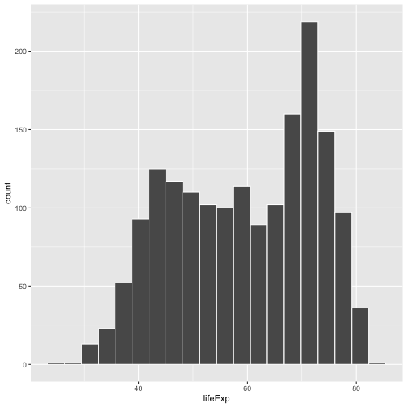

```r
ggplot(data = gapminder,
       mapping = aes(x = lifeExp))+
  geom_histogram(bins = 20,
                 color = "white")
```

Recall that the y-aesthetic of a histogram — the count of the observations in each bin — gets computed automatically. We can use the `after_stat()` argument within `geom_histogram()` to generate percent values as our y-aesthetic.

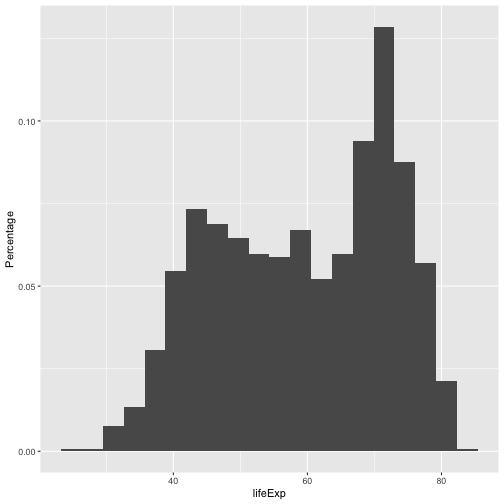

```r
ggplot(data = gapminder,
       mapping = aes(x = lifeExp)) +
  geom_histogram(aes(y = after_stat(count/sum(count))),
                   bins = 20) +
  labs(y = "Percentage")
```

### Coordinate Systems

We can switch the axes on a plot with `coord_flip()`. Consider the faceted scatterplot we previously created.

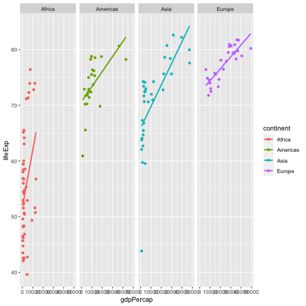

```r
ggplot(data = gapminder_filt,
       mapping = aes(x = gdpPercap,
                     y = lifeExp,
                     color = continent)) +
  geom_point() +
  facet_wrap(~ continent, nrow = 1) +
  geom_smooth(method = "lm",
              formula = y ~ x,
              se = FALSE)
```

Adding the layer `coord_flip()` flips the axes.

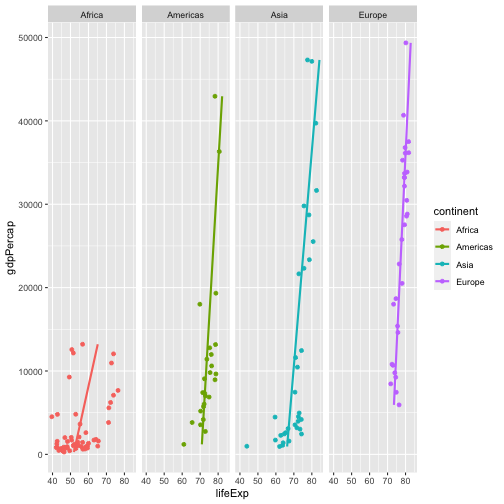

```r
ggplot(data = gapminder_filt,
       mapping = aes(x = gdpPercap,
                     y = lifeExp,
                     color = continent)) +
  geom_point() +
  facet_wrap(~ continent, nrow = 1) +
  geom_smooth(method = "lm",
              formula = y ~ x,
              se = FALSE) +
  coord_flip()
```

`lifeExp` is now on the x-axis and `gdpPercap` on the y-axis. Compared to the previous plot it is now easier to observe the distribution of life expectancy in the respective continents. For example, we can see that many countries in Africa are at about 55 years, in the Americas and Asia at 75 years, and in Europe at 80 years. However, we think it makes more sense to consider `lifeExp` as the dependent variable, so we won't use `coord_flip()` in subsequent plots.

### Axis Limits and Scales

We can also manipulate the limits of the axes by using `xlim()` and `ylim()` within a call to `coord_cartesian()`. For example, assume that we are only interested in countries with a GDP per capita from 0 to 30,000. Recall that, because `data` is the first argument and `mapping` is the second to `ggplot()`, we don't actually have to name the arguments. We can just provide them, as long as they are in the correct order.

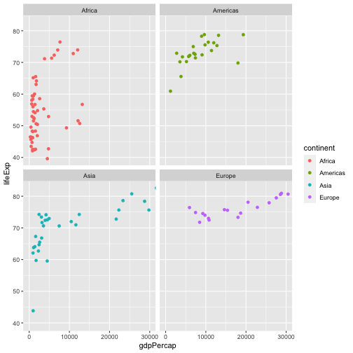

```r
ggplot(gapminder_filt,
       aes(x = gdpPercap, y = lifeExp, color = continent)) +
  geom_point() +
  facet_wrap(~ continent) +
  coord_cartesian(xlim = c(0, 30000))
```

We can see that the GDP per capita on the x-axis is now only shown from 0 to 30,000.

We can also change the scaling of the axes. For example, it might be useful to display the axes on a logarithmic scale by using `scale_x_log10()` or `scale_y_log10()`. Also, note that we can (lazily!) not provide the explicit `x` and `y` argument names to `aes()` as long as we provide the values in the right order: `x` comes before `y`.

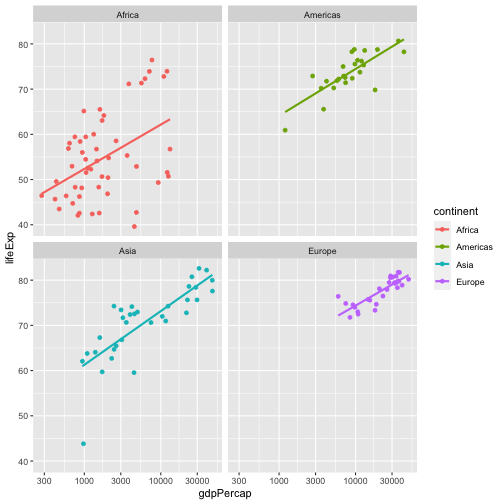

```r
ggplot(gapminder_filt,
       aes(gdpPercap, lifeExp, color = continent)) +
  geom_point() +
  facet_wrap(~ continent) +
  geom_smooth(formula = y ~ x, method = "lm", se = FALSE) +
  scale_x_log10()
```

### Text

Recall we use `labs()` to add labels and titles to our plots. We can also change labels inside the plots using `geom_text()`.

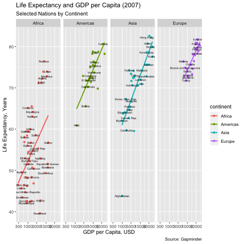

```r
ggplot(gapminder_filt,
       aes(gdpPercap, lifeExp, color = continent)) +
  geom_point() +
  facet_wrap(~ continent, nrow = 1) +
  geom_smooth(formula = y ~ x, method = "lm", se = FALSE) +
  scale_x_log10() +
  labs(title = "Life Expectancy and GDP per Capita (2007)",
       subtitle = "Selected Nations by Continent",
       x = "GDP per Capita, USD",
       y = "Life Expectancy, Years",
       caption = "Source: Gapminder") +
  geom_text(aes(label = country),
            size = 2,
            color = "black",
            check_overlap = TRUE)
```

Let's breakdown the code within `geom_text()`. We included a new aesthetic called *label*. This defines the character variable which will be used as the basis for the labels. We set `label` to country so each point corresponds to the country it represents. We set the text font by setting `size` to 2, and we set the text color by using `color`. Finally, we included the argument `check_overlap = TRUE` to make sure the names of the countries were legible.